# Risk Factor Analysis

## Outcome Variable

**Outcome Variable:** haz

## Predictor Variables

**Intervention Variable:** meducyrs

**Adjustment Set:**

unadjusted

## Stratifying Variables

The analysis was stratified on these variable(s):

- agecat
- studyid
- country

## Data Summary

| agecat | studyid | country | meducyrs | n_cell | n |
| --- | --- | --- | --- | --- | --- |
| Birth | CMC-V-BCS-2002 | INDIA | High | 51 | 92 |
| Birth | CMC-V-BCS-2002 | INDIA | Low | 16 | 92 |
| Birth | CMC-V-BCS-2002 | INDIA | Medium | 25 | 92 |
| Birth | COHORTS | GUATEMALA | High | 178 | 842 |
| Birth | COHORTS | GUATEMALA | Low | 391 | 842 |
| Birth | COHORTS | GUATEMALA | Medium | 273 | 842 |
| Birth | COHORTS | INDIA | High | 678 | 5216 |
| Birth | COHORTS | INDIA | Low | 1756 | 5216 |
| Birth | COHORTS | INDIA | Medium | 2782 | 5216 |
| Birth | COHORTS | PHILIPPINES | High | 1169 | 3050 |
| Birth | COHORTS | PHILIPPINES | Low | 900 | 3050 |
| Birth | COHORTS | PHILIPPINES | Medium | 981 | 3050 |
| Birth | EE | PAKISTAN | High | 7 | 239 |
| Birth | EE | PAKISTAN | Low | 215 | 239 |
| Birth | EE | PAKISTAN | Medium | 17 | 239 |
| Birth | GMS-Nepal | NEPAL | High | 85 | 693 |
| Birth | GMS-Nepal | NEPAL | Low | 485 | 693 |
| Birth | GMS-Nepal | NEPAL | Medium | 123 | 693 |
| Birth | IRC | INDIA | High | 113 | 388 |
| Birth | IRC | INDIA | Low | 142 | 388 |
| Birth | IRC | INDIA | Medium | 133 | 388 |
| Birth | JiVitA-3 | BANGLADESH | High | 6683 | 22427 |
| Birth | JiVitA-3 | BANGLADESH | Low | 8795 | 22427 |
| Birth | JiVitA-3 | BANGLADESH | Medium | 6949 | 22427 |
| Birth | JiVitA-4 | BANGLADESH | High | 933 | 2817 |
| Birth | JiVitA-4 | BANGLADESH | Low | 990 | 2817 |
| Birth | JiVitA-4 | BANGLADESH | Medium | 894 | 2817 |
| Birth | MAL-ED | BANGLADESH | High | 67 | 187 |
| Birth | MAL-ED | BANGLADESH | Low | 65 | 187 |
| Birth | MAL-ED | BANGLADESH | Medium | 55 | 187 |

[output cut: 183 more lines]

The following strata were considered:

- agecat: 24 months, studyid: CMC-V-BCS-2002, country: INDIA
- agecat: 24 months, studyid: COHORTS, country: GUATEMALA
- agecat: 24 months, studyid: COHORTS, country: INDIA
- agecat: 24 months, studyid: COHORTS, country: PHILIPPINES
- agecat: 24 months, studyid: EE, country: PAKISTAN
- agecat: 24 months, studyid: GMS-Nepal, country: NEPAL
- agecat: 24 months, studyid: IRC, country: INDIA
- agecat: 24 months, studyid: JiVitA-3, country: BANGLADESH
- agecat: 24 months, studyid: JiVitA-4, country: BANGLADESH
- agecat: 24 months, studyid: LCNI-5, country: MALAWI
- agecat: 24 months, studyid: MAL-ED, country: BANGLADESH
- agecat: 24 months, studyid: MAL-ED, country: BRAZIL
- agecat: 24 months, studyid: MAL-ED, country: INDIA
- agecat: 24 months, studyid: MAL-ED, country: NEPAL
- agecat: 24 months, studyid: MAL-ED, country: PERU
- agecat: 24 months, studyid: MAL-ED, country: SOUTH AFRICA
- agecat: 24 months, studyid: MAL-ED, country: TANZANIA, UNITED REPUBLIC OF
- agecat: 24 months, studyid: NIH-Birth, country: BANGLADESH
- agecat: 24 months, studyid: NIH-Crypto, country: BANGLADESH
- agecat: 24 months, studyid: PROBIT, country: BELARUS
- agecat: 24 months, studyid: PROVIDE, country: BANGLADESH
- agecat: 24 months, studyid: TanzaniaChild2, country: TANZANIA, UNITED REPUBLIC OF
- agecat: 24 months, studyid: ZVITAMBO, country: ZIMBABWE
- agecat: 6 months, studyid: CMC-V-BCS-2002, country: INDIA
- agecat: 6 months, studyid: COHORTS, country: GUATEMALA
- agecat: 6 months, studyid: COHORTS, country: INDIA
- agecat: 6 months, studyid: COHORTS, country: PHILIPPINES
- agecat: 6 months, studyid: EE, country: PAKISTAN
- agecat: 6 months, studyid: GMS-Nepal, country: NEPAL
- agecat: 6 months, studyid: Guatemala BSC, country: GUATEMALA
- agecat: 6 months, studyid: IRC, country: INDIA
- agecat: 6 months, studyid: JiVitA-3, country: BANGLADESH
- agecat: 6 months, studyid: JiVitA-4, country: BANGLADESH
- agecat: 6 months, studyid: LCNI-5, country: MALAWI
- agecat: 6 months, studyid: MAL-ED, country: BANGLADESH
- agecat: 6 months, studyid: MAL-ED, country: BRAZIL
- agecat: 6 months, studyid: MAL-ED, country: INDIA
- agecat: 6 months, studyid: MAL-ED, country: NEPAL
- agecat: 6 months, studyid: MAL-ED, country: PERU
- agecat: 6 months, studyid: MAL-ED, country: SOUTH AFRICA
- agecat: 6 months, studyid: MAL-ED, country: TANZANIA, UNITED REPUBLIC OF
- agecat: 6 months, studyid: NIH-Birth, country: BANGLADESH
- agecat: 6 months, studyid: NIH-Crypto, country: BANGLADESH
- agecat: 6 months, studyid: PROBIT, country: BELARUS
- agecat: 6 months, studyid: PROVIDE, country: BANGLADESH
- agecat: 6 months, studyid: SAS-CompFeed, country: INDIA
- agecat: 6 months, studyid: SAS-FoodSuppl, country: INDIA
- agecat: 6 months, studyid: TanzaniaChild2, country: TANZANIA, UNITED REPUBLIC OF
- agecat: 6 months, studyid: ZVITAMBO, country: ZIMBABWE
- agecat: Birth, studyid: CMC-V-BCS-2002, country: INDIA
- agecat: Birth, studyid: COHORTS, country: GUATEMALA
- agecat: Birth, studyid: COHORTS, country: INDIA
- agecat: Birth, studyid: COHORTS, country: PHILIPPINES
- agecat: Birth, studyid: EE, country: PAKISTAN
- agecat: Birth, studyid: GMS-Nepal, country: NEPAL
- agecat: Birth, studyid: IRC, country: INDIA
- agecat: Birth, studyid: JiVitA-3, country: BANGLADESH
- agecat: Birth, studyid: JiVitA-4, country: BANGLADESH
- agecat: Birth, studyid: MAL-ED, country: BANGLADESH
- agecat: Birth, studyid: MAL-ED, country: BRAZIL
- agecat: Birth, studyid: MAL-ED, country: INDIA
- agecat: Birth, studyid: MAL-ED, country: NEPAL
- agecat: Birth, studyid: MAL-ED, country: PERU
- agecat: Birth, studyid: MAL-ED, country: SOUTH AFRICA
- agecat: Birth, studyid: MAL-ED, country: TANZANIA, UNITED REPUBLIC OF
- agecat: Birth, studyid: NIH-Birth, country: BANGLADESH
- agecat: Birth, studyid: NIH-Crypto, country: BANGLADESH
- agecat: Birth, studyid: PROBIT, country: BELARUS
- agecat: Birth, studyid: PROVIDE, country: BANGLADESH
- agecat: Birth, studyid: SAS-CompFeed, country: INDIA
- agecat: Birth, studyid: ZVITAMBO, country: ZIMBABWE

### Dropped Strata

Some strata were dropped due to rare outcomes:

- agecat: 24 months, studyid: TanzaniaChild2, country: TANZANIA, UNITED REPUBLIC OF

## Methods Detail

We’re interested in the causal parameters $E[Y_a]$ for all values of $a \in \mathcal{A}$. These parameters represent the mean outcome if, possibly contrary to fact, we intervened to set all units to have $A=a$. Under the randomization and positivity assumptions, these are identified by the statistical parameters $\psi_a=E_W[E_{Y|A,W}(Y|A=a,W)]$. In addition, we’re interested in the mean of $Y$, $E[Y]$ under no intervention (the observed mean). We will estimate these parameters by using SuperLearner to fit the relevant likelihood factors – $E_{Y|A,W}(Y|A=a,W)$ and $p(A=a|W)$, and then updating our likelihood fit using a joint TMLE.

For unadjusted analyses ($W=\{\}$), initial likelihoods were estimated using Lrnr_glm to estimate the simple $E(Y|A)$ and Lrnr_mean to estimate $p(A)$. For adjusted analyses, a small library containing Lrnr_glmnet, Lrnr_xgboost, and Lrnr_mean was used.

Having estimated these parameters, we will then use the delta method to estimate relative risks and attributable risks relative to a prespecified baseline level of $A$.

# Results Detail

## Results Plots

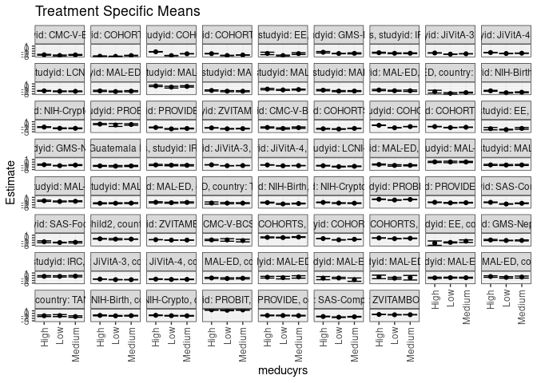

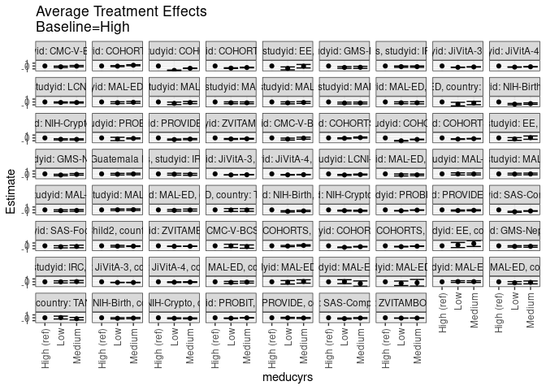

[figure not shown]

## Results Table

### Parameter: TSM

| agecat | studyid | country | intervention_level | baseline_level | estimate | ci_lower | ci_upper |
| --- | --- | --- | --- | --- | --- | --- | --- |
| Birth | CMC-V-BCS-2002 | INDIA | High | NA | -0.8887255 | -1.1392410 | -0.6382100 |
| Birth | CMC-V-BCS-2002 | INDIA | Low | NA | -0.9050000 | -1.4061812 | -0.4038188 |
| Birth | CMC-V-BCS-2002 | INDIA | Medium | NA | -1.1450000 | -1.6583068 | -0.6316932 |
| Birth | COHORTS | GUATEMALA | High | NA | 0.1202247 | -0.0458097 | 0.2862591 |
| Birth | COHORTS | GUATEMALA | Low | NA | 0.0444501 | -0.0868399 | 0.1757402 |
| Birth | COHORTS | GUATEMALA | Medium | NA | 0.2554212 | 0.1131504 | 0.3976920 |
| Birth | COHORTS | INDIA | High | NA | -0.3412684 | -0.4251921 | -0.2573448 |
| Birth | COHORTS | INDIA | Low | NA | -0.8533770 | -0.9081194 | -0.7986345 |
| Birth | COHORTS | INDIA | Medium | NA | -0.6322753 | -0.6747157 | -0.5898350 |
| Birth | COHORTS | PHILIPPINES | High | NA | -0.1277246 | -0.1894408 | -0.0660083 |
| Birth | COHORTS | PHILIPPINES | Low | NA | -0.4007444 | -0.4725217 | -0.3289672 |
| Birth | COHORTS | PHILIPPINES | Medium | NA | -0.2544546 | -0.3238279 | -0.1850814 |
| Birth | EE | PAKISTAN | High | NA | -2.1742857 | -3.0389611 | -1.3096103 |
| Birth | EE | PAKISTAN | Low | NA | -1.8810233 | -2.0830133 | -1.6790332 |
| Birth | EE | PAKISTAN | Medium | NA | -1.3876471 | -1.8873432 | -0.8879509 |
| Birth | GMS-Nepal | NEPAL | High | NA | -0.9247059 | -1.1556669 | -0.6937449 |
| Birth | GMS-Nepal | NEPAL | Low | NA | -1.1134433 | -1.2085962 | -1.0182904 |
| Birth | GMS-Nepal | NEPAL | Medium | NA | -1.0991057 | -1.2927159 | -0.9054955 |
| Birth | IRC | INDIA | High | NA | -0.3259292 | -0.6063276 | -0.0455308 |
| Birth | IRC | INDIA | Low | NA | -0.3416901 | -0.5985971 | -0.0847832 |
| Birth | IRC | INDIA | Medium | NA | -0.2569173 | -0.5532520 | 0.0394175 |
| Birth | JiVitA-3 | BANGLADESH | High | NA | -1.4306374 | -1.4623333 | -1.3989416 |
| Birth | JiVitA-3 | BANGLADESH | Low | NA | -1.6552791 | -1.6829414 | -1.6276169 |
| Birth | JiVitA-3 | BANGLADESH | Medium | NA | -1.6597064 | -1.6906568 | -1.6287561 |
| Birth | JiVitA-4 | BANGLADESH | High | NA | -1.4437728 | -1.5357068 | -1.3518388 |
| Birth | JiVitA-4 | BANGLADESH | Low | NA | -1.5756970 | -1.6610523 | -1.4903416 |
| Birth | JiVitA-4 | BANGLADESH | Medium | NA | -1.5481320 | -1.6262669 | -1.4699971 |
| Birth | MAL-ED | BANGLADESH | High | NA | -0.9826866 | -1.2124817 | -0.7528914 |
| Birth | MAL-ED | BANGLADESH | Low | NA | -1.1964615 | -1.4724514 | -0.9204716 |
| Birth | MAL-ED | BANGLADESH | Medium | NA | -1.0896364 | -1.3378241 | -0.8414486 |

[output cut: 180 more lines]

### Parameter: E(Y)

| agecat | studyid | country | intervention_level | baseline_level | estimate | ci_lower | ci_upper |
| --- | --- | --- | --- | --- | --- | --- | --- |
| Birth | CMC-V-BCS-2002 | INDIA | NA | NA | -0.9611957 | -1.1776967 | -0.7446946 |
| Birth | COHORTS | GUATEMALA | NA | NA | 0.1288717 | 0.0445170 | 0.2132265 |
| Birth | COHORTS | INDIA | NA | NA | -0.6688842 | -0.7003528 | -0.6374156 |
| Birth | COHORTS | PHILIPPINES | NA | NA | -0.2490492 | -0.2880580 | -0.2100404 |
| Birth | EE | PAKISTAN | NA | NA | -1.8545188 | -2.0422173 | -1.6668203 |
| Birth | GMS-Nepal | NEPAL | NA | NA | -1.0877489 | -1.1679913 | -1.0075066 |
| Birth | IRC | INDIA | NA | NA | -0.3080412 | -0.4687931 | -0.1472894 |
| Birth | JiVitA-3 | BANGLADESH | NA | NA | -1.5897102 | -1.6089975 | -1.5704229 |
| Birth | JiVitA-4 | BANGLADESH | NA | NA | -1.5232552 | -1.5724840 | -1.4740265 |
| Birth | MAL-ED | BANGLADESH | NA | NA | -1.0884492 | -1.2349987 | -0.9418997 |
| Birth | MAL-ED | BRAZIL | NA | NA | -0.6760000 | -0.9521457 | -0.3998543 |
| Birth | MAL-ED | INDIA | NA | NA | -1.2372500 | -1.5471753 | -0.9273247 |
| Birth | MAL-ED | NEPAL | NA | NA | -0.9120000 | -1.2873301 | -0.5366699 |
| Birth | MAL-ED | PERU | NA | NA | -0.8827897 | -1.0001058 | -0.7654736 |
| Birth | MAL-ED | SOUTH AFRICA | NA | NA | -0.6317073 | -0.8249555 | -0.4384591 |
| Birth | MAL-ED | TANZANIA, UNITED REPUBLIC OF | NA | NA | -1.1398095 | -1.3671021 | -0.9125169 |
| Birth | NIH-Birth | BANGLADESH | NA | NA | -0.9310197 | -1.0197391 | -0.8423003 |
| Birth | NIH-Crypto | BANGLADESH | NA | NA | -0.9094945 | -0.9809370 | -0.8380521 |
| Birth | PROBIT | BELARUS | NA | NA | 1.3114417 | 1.1524752 | 1.4704082 |
| Birth | PROVIDE | BANGLADESH | NA | NA | -0.8851020 | -0.9601332 | -0.8100709 |
| Birth | SAS-CompFeed | INDIA | NA | NA | -1.4314217 | -1.5099245 | -1.3529189 |
| Birth | ZVITAMBO | ZIMBABWE | NA | NA | -0.5006712 | -0.5212382 | -0.4801043 |
| 6 months | CMC-V-BCS-2002 | INDIA | NA | NA | -1.4234508 | -1.5645974 | -1.2823042 |
| 6 months | COHORTS | GUATEMALA | NA | NA | -1.8103361 | -1.8786415 | -1.7420307 |
| 6 months | COHORTS | INDIA | NA | NA | -1.0183078 | -1.0495042 | -0.9871113 |
| 6 months | COHORTS | PHILIPPINES | NA | NA | -1.1405724 | -1.1824954 | -1.0986493 |
| 6 months | EE | PAKISTAN | NA | NA | -2.0782207 | -2.1981595 | -1.9582820 |
| 6 months | GMS-Nepal | NEPAL | NA | NA | -1.3508616 | -1.4293975 | -1.2723256 |
| 6 months | Guatemala BSC | GUATEMALA | NA | NA | -1.5624368 | -1.6783540 | -1.4465196 |
| 6 months | IRC | INDIA | NA | NA | -1.2344062 | -1.3658524 | -1.1029600 |
| 6 months | JiVitA-3 | BANGLADESH | NA | NA | -1.3131339 | -1.3362896 | -1.2899781 |
| 6 months | JiVitA-4 | BANGLADESH | NA | NA | -1.3449232 | -1.3822755 | -1.3075709 |
| 6 months | LCNI-5 | MALAWI | NA | NA | -1.6431488 | -1.7125598 | -1.5737379 |
| 6 months | MAL-ED | BANGLADESH | NA | NA | -1.1932738 | -1.3246079 | -1.0619397 |
| 6 months | MAL-ED | BRAZIL | NA | NA | 0.0494712 | -0.0951008 | 0.1940431 |
| 6 months | MAL-ED | INDIA | NA | NA | -1.1605449 | -1.2821450 | -1.0389448 |
| 6 months | MAL-ED | NEPAL | NA | NA | -0.5481599 | -0.6614541 | -0.4348656 |
| 6 months | MAL-ED | PERU | NA | NA | -1.3277482 | -1.4358597 | -1.2196367 |
| 6 months | MAL-ED | SOUTH AFRICA | NA | NA | -1.0633202 | -1.1909180 | -0.9357224 |
| 6 months | MAL-ED | TANZANIA, UNITED REPUBLIC OF | NA | NA | -1.2937438 | -1.4246923 | -1.1627954 |
| 6 months | NIH-Birth | BANGLADESH | NA | NA | -1.4073821 | -1.4960598 | -1.3187043 |
| 6 months | NIH-Crypto | BANGLADESH | NA | NA | -1.1986783 | -1.2700937 | -1.1272630 |
| 6 months | PROBIT | BELARUS | NA | NA | 0.0980074 | 0.0062724 | 0.1897424 |
| 6 months | PROVIDE | BANGLADESH | NA | NA | -1.0916915 | -1.1661176 | -1.0172654 |
| 6 months | SAS-CompFeed | INDIA | NA | NA | -1.4018563 | -1.4810585 | -1.3226541 |
| 6 months | SAS-FoodSuppl | INDIA | NA | NA | -1.8986842 | -2.0118892 | -1.7854792 |
| 6 months | TanzaniaChild2 | TANZANIA, UNITED REPUBLIC OF | NA | NA | -0.5440108 | -0.5930025 | -0.4950192 |
| 6 months | ZVITAMBO | ZIMBABWE | NA | NA | -0.8688556 | -0.8944357 | -0.8432754 |
| 24 months | CMC-V-BCS-2002 | INDIA | NA | NA | -2.5588679 | -2.6583730 | -2.4593629 |
| 24 months | COHORTS | GUATEMALA | NA | NA | -2.9885052 | -3.0530889 | -2.9239215 |
| 24 months | COHORTS | INDIA | NA | NA | -2.1741663 | -2.2109368 | -2.1373958 |
| 24 months | COHORTS | PHILIPPINES | NA | NA | -2.4141145 | -2.4590818 | -2.3691473 |
| 24 months | EE | PAKISTAN | NA | NA | -2.6563232 | -2.8000905 | -2.5125560 |
| 24 months | GMS-Nepal | NEPAL | NA | NA | -1.8887629 | -1.9746814 | -1.8028444 |
| 24 months | IRC | INDIA | NA | NA | -1.7987775 | -1.8923914 | -1.7051636 |
| 24 months | JiVitA-3 | BANGLADESH | NA | NA | -2.0134370 | -2.0411067 | -1.9857672 |
| 24 months | JiVitA-4 | BANGLADESH | NA | NA | -1.7814786 | -1.8170130 | -1.7459442 |
| 24 months | LCNI-5 | MALAWI | NA | NA | -1.8795105 | -1.9611410 | -1.7978800 |
| 24 months | MAL-ED | BANGLADESH | NA | NA | -1.9096199 | -2.0438307 | -1.7754091 |
| 24 months | MAL-ED | BRAZIL | NA | NA | 0.0081448 | -0.1615145 | 0.1778041 |
| 24 months | MAL-ED | INDIA | NA | NA | -1.8274372 | -1.9559249 | -1.6989495 |
| 24 months | MAL-ED | NEPAL | NA | NA | -1.2688028 | -1.3908231 | -1.1467825 |
| 24 months | MAL-ED | PERU | NA | NA | -1.7545083 | -1.8762212 | -1.6327955 |
| 24 months | MAL-ED | SOUTH AFRICA | NA | NA | -1.6450595 | -1.7797240 | -1.5103950 |
| 24 months | MAL-ED | TANZANIA, UNITED REPUBLIC OF | NA | NA | -2.5654000 | -2.7089193 | -2.4218807 |
| 24 months | NIH-Birth | BANGLADESH | NA | NA | -2.2190579 | -2.3217459 | -2.1163699 |
| 24 months | NIH-Crypto | BANGLADESH | NA | NA | -1.4412646 | -1.5249156 | -1.3576135 |
| 24 months | PROBIT | BELARUS | NA | NA | -0.1442891 | -0.4253755 | 0.1367972 |
| 24 months | PROVIDE | BANGLADESH | NA | NA | -1.6024221 | -1.6857420 | -1.5191023 |
| 24 months | ZVITAMBO | ZIMBABWE | NA | NA | -1.6059152 | -1.6629321 | -1.5488983 |

### Parameter: ATE

| agecat | studyid | country | intervention_level | baseline_level | estimate | ci_lower | ci_upper |
| --- | --- | --- | --- | --- | --- | --- | --- |
| Birth | CMC-V-BCS-2002 | INDIA | High | High | 0.0000000 | 0.0000000 | 0.0000000 |
| Birth | CMC-V-BCS-2002 | INDIA | Low | High | -0.0162745 | -0.5765786 | 0.5440295 |
| Birth | CMC-V-BCS-2002 | INDIA | Medium | High | -0.2562745 | -0.8274504 | 0.3149014 |
| Birth | COHORTS | GUATEMALA | High | High | 0.0000000 | 0.0000000 | 0.0000000 |
| Birth | COHORTS | GUATEMALA | Low | High | -0.0757746 | -0.2874453 | 0.1358961 |
| Birth | COHORTS | GUATEMALA | Medium | High | 0.1351965 | -0.0834548 | 0.3538479 |
| Birth | COHORTS | INDIA | High | High | 0.0000000 | 0.0000000 | 0.0000000 |
| Birth | COHORTS | INDIA | Low | High | -0.5121086 | -0.6123079 | -0.4119092 |
| Birth | COHORTS | INDIA | Medium | High | -0.2910069 | -0.3850514 | -0.1969624 |
| Birth | COHORTS | PHILIPPINES | High | High | 0.0000000 | 0.0000000 | 0.0000000 |
| Birth | COHORTS | PHILIPPINES | Low | High | -0.2730199 | -0.3676817 | -0.1783580 |
| Birth | COHORTS | PHILIPPINES | Medium | High | -0.1267301 | -0.2195823 | -0.0338778 |
| Birth | EE | PAKISTAN | High | High | 0.0000000 | 0.0000000 | 0.0000000 |
| Birth | EE | PAKISTAN | Low | High | 0.2932625 | -0.5946922 | 1.1812171 |
| Birth | EE | PAKISTAN | Medium | High | 0.7866387 | -0.2120403 | 1.7853176 |
| Birth | GMS-Nepal | NEPAL | High | High | 0.0000000 | 0.0000000 | 0.0000000 |
| Birth | GMS-Nepal | NEPAL | Low | High | -0.1887374 | -0.4385315 | 0.0610566 |
| Birth | GMS-Nepal | NEPAL | Medium | High | -0.1743998 | -0.4757765 | 0.1269769 |
| Birth | IRC | INDIA | High | High | 0.0000000 | 0.0000000 | 0.0000000 |
| Birth | IRC | INDIA | Low | High | -0.0157609 | -0.3960561 | 0.3645342 |
| Birth | IRC | INDIA | Medium | High | 0.0690119 | -0.3389557 | 0.4769795 |
| Birth | JiVitA-3 | BANGLADESH | High | High | 0.0000000 | 0.0000000 | 0.0000000 |
| Birth | JiVitA-3 | BANGLADESH | Low | High | -0.2246417 | -0.2636274 | -0.1856560 |
| Birth | JiVitA-3 | BANGLADESH | Medium | High | -0.2290690 | -0.2719839 | -0.1861541 |
| Birth | JiVitA-4 | BANGLADESH | High | High | 0.0000000 | 0.0000000 | 0.0000000 |
| Birth | JiVitA-4 | BANGLADESH | Low | High | -0.1319242 | -0.2569895 | -0.0068589 |
| Birth | JiVitA-4 | BANGLADESH | Medium | High | -0.1043592 | -0.2267229 | 0.0180045 |
| Birth | MAL-ED | BANGLADESH | High | High | 0.0000000 | 0.0000000 | 0.0000000 |
| Birth | MAL-ED | BANGLADESH | Low | High | -0.2137750 | -0.5729076 | 0.1453577 |
| Birth | MAL-ED | BANGLADESH | Medium | High | -0.1069498 | -0.4451849 | 0.2312853 |

[output cut: 180 more lines]

### Parameter: PAR

| agecat | studyid | country | intervention_level | baseline_level | estimate | ci_lower | ci_upper |
| --- | --- | --- | --- | --- | --- | --- | --- |
| Birth | CMC-V-BCS-2002 | INDIA | High | NA | -0.0724702 | -0.2725980 | 0.1276577 |
| Birth | COHORTS | GUATEMALA | High | NA | 0.0086470 | -0.1431013 | 0.1603954 |
| Birth | COHORTS | INDIA | High | NA | -0.3276158 | -0.4063714 | -0.2488602 |
| Birth | COHORTS | PHILIPPINES | High | NA | -0.1213246 | -0.1704250 | -0.0722243 |
| Birth | EE | PAKISTAN | High | NA | 0.3197669 | -0.5399412 | 1.1794750 |
| Birth | GMS-Nepal | NEPAL | High | NA | -0.1630430 | -0.3791362 | 0.0530501 |
| Birth | IRC | INDIA | High | NA | 0.0178880 | -0.2243276 | 0.2601036 |
| Birth | JiVitA-3 | BANGLADESH | High | NA | -0.1590727 | -0.1841918 | -0.1339537 |
| Birth | JiVitA-4 | BANGLADESH | High | NA | -0.0794825 | -0.1528469 | -0.0061181 |
| Birth | MAL-ED | BANGLADESH | High | NA | -0.1057626 | -0.2966634 | 0.0851381 |
| Birth | MAL-ED | BRAZIL | High | NA | 0.0045556 | -0.3519272 | 0.3610383 |
| Birth | MAL-ED | INDIA | High | NA | -0.1885000 | -0.7564850 | 0.3794850 |
| Birth | MAL-ED | NEPAL | High | NA | -0.3560000 | -1.0206118 | 0.3086118 |
| Birth | MAL-ED | PERU | High | NA | 0.0495632 | -0.1419526 | 0.2410791 |
| Birth | MAL-ED | SOUTH AFRICA | High | NA | -0.2177073 | -0.4924209 | 0.0570063 |
| Birth | MAL-ED | TANZANIA, UNITED REPUBLIC OF | High | NA | -0.1726667 | -0.5399274 | 0.1945941 |
| Birth | NIH-Birth | BANGLADESH | High | NA | -0.1051962 | -0.2510601 | 0.0406677 |
| Birth | NIH-Crypto | BANGLADESH | High | NA | -0.1248792 | -0.2259235 | -0.0238348 |
| Birth | PROBIT | BELARUS | High | NA | -0.0690251 | -0.1390664 | 0.0010161 |
| Birth | PROVIDE | BANGLADESH | High | NA | -0.0390786 | -0.1485743 | 0.0704170 |
| Birth | SAS-CompFeed | INDIA | High | NA | -0.1605750 | -0.2887673 | -0.0323826 |
| Birth | ZVITAMBO | ZIMBABWE | High | NA | -0.0492727 | -0.0681398 | -0.0304056 |
| 6 months | CMC-V-BCS-2002 | INDIA | High | NA | -0.1355633 | -0.2993206 | 0.0281940 |
| 6 months | COHORTS | GUATEMALA | High | NA | -0.0139037 | -0.1481526 | 0.1203452 |
| 6 months | COHORTS | INDIA | High | NA | -0.6085388 | -0.6829736 | -0.5341039 |
| 6 months | COHORTS | PHILIPPINES | High | NA | -0.2071010 | -0.2602500 | -0.1539520 |
| 6 months | EE | PAKISTAN | High | NA | -0.3083318 | -0.7591711 | 0.1425074 |
| 6 months | GMS-Nepal | NEPAL | High | NA | -0.2983861 | -0.5112702 | -0.0855020 |
| 6 months | Guatemala BSC | GUATEMALA | High | NA | -0.0350864 | -0.1696804 | 0.0995076 |
| 6 months | IRC | INDIA | High | NA | -0.0853683 | -0.2764190 | 0.1056824 |
| 6 months | JiVitA-3 | BANGLADESH | High | NA | -0.2091487 | -0.2336782 | -0.1846193 |
| 6 months | JiVitA-4 | BANGLADESH | High | NA | -0.1886834 | -0.2338326 | -0.1435341 |
| 6 months | LCNI-5 | MALAWI | High | NA | -0.1841220 | -0.2745399 | -0.0937041 |
| 6 months | MAL-ED | BANGLADESH | High | NA | -0.2187761 | -0.3810488 | -0.0565034 |
| 6 months | MAL-ED | BRAZIL | High | NA | -0.0146838 | -0.2118804 | 0.1825129 |
| 6 months | MAL-ED | INDIA | High | NA | -0.0259968 | -0.2100674 | 0.1580737 |
| 6 months | MAL-ED | NEPAL | High | NA | -0.1799838 | -0.3830759 | 0.0231084 |
| 6 months | MAL-ED | PERU | High | NA | 0.0332704 | -0.1298271 | 0.1963678 |
| 6 months | MAL-ED | SOUTH AFRICA | High | NA | -0.0967250 | -0.3001597 | 0.1067097 |
| 6 months | MAL-ED | TANZANIA, UNITED REPUBLIC OF | High | NA | -0.0380031 | -0.4665502 | 0.3905440 |
| 6 months | NIH-Birth | BANGLADESH | High | NA | -0.3203928 | -0.4559404 | -0.1848452 |
| 6 months | NIH-Crypto | BANGLADESH | High | NA | -0.1910533 | -0.2907232 | -0.0913834 |
| 6 months | PROBIT | BELARUS | High | NA | -0.1506678 | -0.2118530 | -0.0894826 |
| 6 months | PROVIDE | BANGLADESH | High | NA | -0.1208462 | -0.2209799 | -0.0207125 |
| 6 months | SAS-CompFeed | INDIA | High | NA | -0.4274253 | -0.5207349 | -0.3341156 |
| 6 months | SAS-FoodSuppl | INDIA | High | NA | -0.2786842 | -0.6185159 | 0.0611474 |
| 6 months | TanzaniaChild2 | TANZANIA, UNITED REPUBLIC OF | High | NA | -0.0890661 | -0.1766419 | -0.0014904 |
| 6 months | ZVITAMBO | ZIMBABWE | High | NA | -0.0679134 | -0.0913729 | -0.0444539 |
| 24 months | CMC-V-BCS-2002 | INDIA | High | NA | -0.0934987 | -0.2113776 | 0.0243802 |
| 24 months | COHORTS | GUATEMALA | High | NA | 0.0604422 | -0.0706787 | 0.1915630 |
| 24 months | COHORTS | INDIA | High | NA | -0.9019952 | -0.9796860 | -0.8243045 |
| 24 months | COHORTS | PHILIPPINES | High | NA | -0.3960511 | -0.4540025 | -0.3380997 |
| 24 months | EE | PAKISTAN | High | NA | -0.7263232 | -1.2203870 | -0.2322594 |
| 24 months | GMS-Nepal | NEPAL | High | NA | -0.4432174 | -0.7034093 | -0.1830255 |
| 24 months | IRC | INDIA | High | NA | -0.1557668 | -0.2999908 | -0.0115427 |
| 24 months | JiVitA-3 | BANGLADESH | High | NA | -0.2629177 | -0.2959519 | -0.2298834 |
| 24 months | JiVitA-4 | BANGLADESH | High | NA | -0.2059892 | -0.2477746 | -0.1642038 |
| 24 months | LCNI-5 | MALAWI | High | NA | -0.1141469 | -0.2151680 | -0.0131257 |
| 24 months | MAL-ED | BANGLADESH | High | NA | -0.1146980 | -0.2972120 | 0.0678160 |
| 24 months | MAL-ED | BRAZIL | High | NA | -0.1967476 | -0.4130394 | 0.0195441 |
| 24 months | MAL-ED | INDIA | High | NA | -0.2128008 | -0.4096083 | -0.0159933 |
| 24 months | MAL-ED | NEPAL | High | NA | -0.1917195 | -0.4329148 | 0.0494759 |
| 24 months | MAL-ED | PERU | High | NA | -0.2581806 | -0.4575842 | -0.0587771 |
| 24 months | MAL-ED | SOUTH AFRICA | High | NA | -0.2072237 | -0.4180120 | 0.0035645 |
| 24 months | MAL-ED | TANZANIA, UNITED REPUBLIC OF | High | NA | -0.4711143 | -1.0216088 | 0.0793802 |
| 24 months | NIH-Birth | BANGLADESH | High | NA | -0.4653143 | -0.6223360 | -0.3082926 |
| 24 months | NIH-Crypto | BANGLADESH | High | NA | -0.3086468 | -0.4157598 | -0.2015338 |
| 24 months | PROBIT | BELARUS | High | NA | -0.2026827 | -0.4111140 | 0.0057486 |
| 24 months | PROVIDE | BANGLADESH | High | NA | -0.3107057 | -0.4223915 | -0.1990199 |
| 24 months | ZVITAMBO | ZIMBABWE | High | NA | -0.1520405 | -0.2061229 | -0.0979580 |